## 8. Integrated Exploratory Data Analysis

The previous analyses showed several patterns involving season, weather, temperature, and bike rentals. This section investigates three questions that combine several variables to better understand bike-sharing activity.

### 8.1 Does Bike Usage Differ Across Seasons for Casual and Registered Users?

**Question:** Does the number of bike rentals differ across seasons, and is the seasonal pattern the same for casual and registered users?

**Relevant variables:** `season`, `casual`, and `registered`.

```r
# Mean casual rentals by season
tapply(bike$casual, bike$season, mean)
```

```
##    Winter    Spring    Summer      Fall
##  334.9282 1106.0978 1202.6117  729.1124
```

```r
# Mean registered rentals by season
tapply(bike$registered, bike$season, mean)
```

```
##   Winter   Spring   Summer     Fall
## 2269.204 3886.234 4441.691 3999.051
```

```r
# Median casual rentals by season
tapply(bike$casual, bike$season, median)
```

```
## Winter Spring Summer   Fall
##  218.0  867.0 1050.5  544.5
```

```r
# Median registered rentals by season
tapply(bike$registered, bike$season, median)
```

```
## Winter Spring Summer   Fall
## 1867.0 3844.0 4110.5 3815.0
```

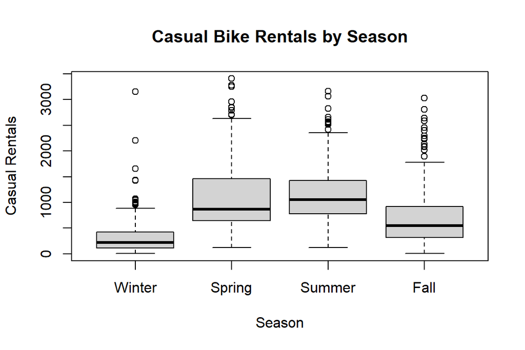

```r
# Casual rentals by season
boxplot(casual ~ season,
        data = bike,
        main = "Casual Bike Rentals by Season",
        xlab = "Season",
        ylab = "Casual Rentals")
```

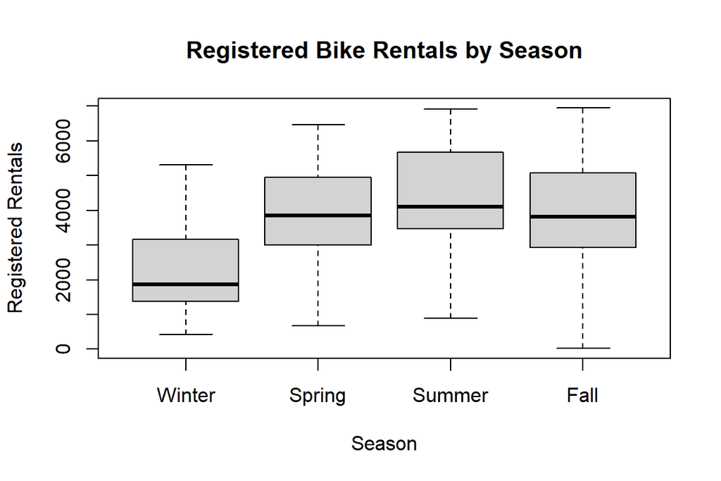

```r
# Registered rentals by season
boxplot(registered ~ season,
        data = bike,
        main = "Registered Bike Rentals by Season",
        xlab = "Season",
        ylab = "Registered Rentals")
```

Casual and registered bike rentals both differ across seasons. For casual users, Summer has the highest mean number of rentals (1202.6), followed by Spring (1106.1), Fall (729.1), and Winter (334.9). The medians show the same general pattern, with Summer having the highest median and Winter the lowest.

Registered users also have their highest mean rentals in Summer (4441.7) and their lowest in Winter (2269.2). However, registered rentals remain relatively high in both Spring and Fall. The boxplots show that Winter has a clearly lower center for both types of users.

The seasonal pattern exists for both casual and registered users, but it is especially noticeable for casual users. Casual bike usage increases greatly from Winter to Spring and Summer, while registered usage remains comparatively high across Spring, Summer, and Fall. The casual-rental boxplots also show several potential high outliers.

These results show an association between season and bike usage, but they do not show that season causes the differences. Temperature, weather conditions, working-day status, and other variables may also be related to the observed seasonal pattern.

### 8.2 Does the Relationship Between Temperature and Bike Rentals Change Across Weather Conditions?

**Question:** Is the relationship between temperature and total bike rentals the same under different weather conditions?

**Relevant variables:** `temp`, `cnt`, and `weathersit`.

```r
# Overall correlation
cor(bike$temp, bike$cnt)
```

```
## [1] 0.627494
```

```r
# Correlation during Clear/Few Clouds
cor(bike$temp[bike$weathersit == "Clear/Few Clouds"],
    bike$cnt[bike$weathersit == "Clear/Few Clouds"])
```

```
## [1] 0.6221905
```

```r
# Correlation during Mist/Cloudy weather
cor(bike$temp[bike$weathersit == "Mist/Cloudy"],
    bike$cnt[bike$weathersit == "Mist/Cloudy"])
```

```
## [1] 0.6449123
```

```r
# Correlation during Light Snow/Rain
cor(bike$temp[bike$weathersit == "Light Snow/Rain"],
    bike$cnt[bike$weathersit == "Light Snow/Rain"])
```

```
## [1] 0.6068586
```

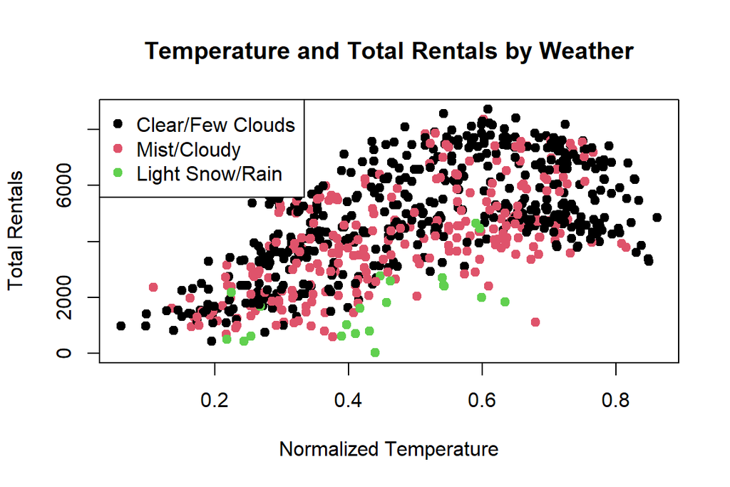

```r
# Temperature and total rentals by weather situation
plot(bike$temp, bike$cnt,
     col = as.numeric(bike$weathersit),
     pch = 19,
     main = "Temperature and Total Rentals by Weather",
     xlab = "Normalized Temperature",
     ylab = "Total Rentals")

legend("topleft",
       legend = levels(bike$weathersit),
       col = 1:length(levels(bike$weathersit)),
       pch = 19)
```

The overall correlation between temperature and total bike rentals is 0.6275, showing a positive relationship. When the data are separated by weather situation, the correlations are 0.6222 for Clear/Few Clouds, 0.6449 for Mist/Cloudy, and 0.6069 for Light Snow/Rain.

All three correlations are positive and similar in magnitude. Therefore, the positive relationship between temperature and total rentals remains present across all three weather conditions. Mist/Cloudy weather has the strongest correlation and Light Snow/Rain has the weakest, but the differences are relatively small.

The scatterplot also shows that days with Light Snow/Rain generally have lower rental counts than days with Clear/Few Clouds or Mist/Cloudy weather. There are also far fewer observations in the Light Snow/Rain category, so this group’s correlation is based on fewer observations.

Overall, weather condition does not appear to greatly change the direction of the relationship between temperature and rentals because the relationship remains positive in every group. However, weather conditions appear to be associated with the general level of bike usage.

These results describe associations only. They do not establish that higher temperature causes more bike rentals or that a particular weather condition causes lower bike usage.

### 8.3 Does Working-Day Status Affect Casual and Registered Users Differently?

**Question:** Do casual and registered bike rentals differ between working and non-working days, and are the patterns the same for the two types of users?

**Relevant variables:** `workingday`, `casual`, and `registered`.

```r
# Mean rentals by working-day status
tapply(bike$casual, bike$workingday, mean)
```

```
##       No      Yes
## 1371.134  606.570
```

```r
tapply(bike$registered, bike$workingday, mean)
```

```
##       No      Yes
## 2959.035 3978.250
```

```r
# Median rentals by working-day status
tapply(bike$casual, bike$workingday, median)
```

```
##     No    Yes
## 1338.0  616.5
```

```r
tapply(bike$registered, bike$workingday, median)
```

```
##   No  Yes
## 2928 3866
```

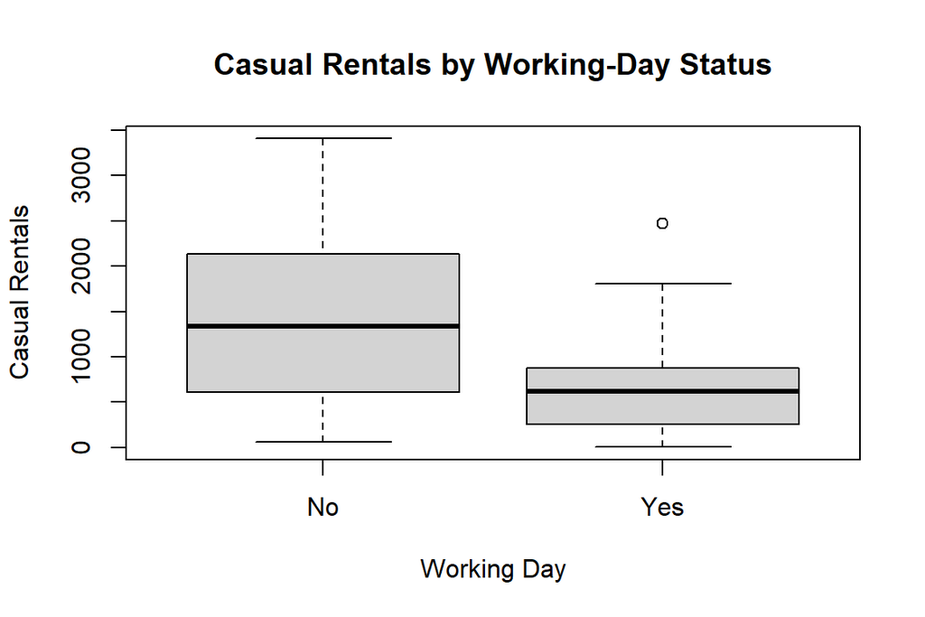

```r
# Casual rentals by working-day status
boxplot(casual ~ workingday,
        data = bike,
        main = "Casual Rentals by Working-Day Status",
        xlab = "Working Day",
        ylab = "Casual Rentals")
```

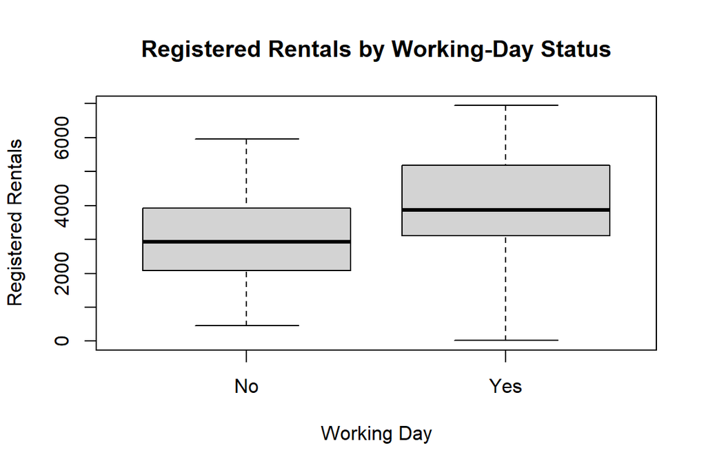

```r
# Registered rentals by working-day status
boxplot(registered ~ workingday,
        data = bike,
        main = "Registered Rentals by Working-Day Status",
        xlab = "Working Day",
        ylab = "Registered Rentals")
```

Working-day status is associated with casual and registered rentals in opposite ways. On non-working days, the mean number of casual rentals is 1371.1, compared with 606.6 on working days. The medians show the same pattern: 1338 casual rentals on non-working days compared with 616.5 on working days.

For registered users, the pattern is reversed. The mean number of registered rentals is 3978.3 on working days compared with 2959.0 on non-working days. The median is also higher on working days, with 3866 registered rentals compared with 2928 on non-working days.

The boxplots support these results. Casual rentals have a substantially higher center on non-working days, while registered rentals have a higher center on working days. Casual rentals also show greater spread on non-working days.

Therefore, working-day status is associated differently with the two types of users. Casual users appear to use the bikes more on non-working days, while registered users use them more on working days. One possible explanation is that registered users may use the service more regularly, including for work-related travel, while casual usage may be more related to leisure. However, the dataset does not record the purpose of each trip, so this explanation cannot be confirmed from these data.

The analysis shows an association between working-day status and rental behavior, not causation. Season, temperature, weather, holidays, and other factors may also contribute to these differences.

## 9. Outliers and Unusual Observations

Potentially unusual observations identified during the previous analyses were investigated using the boxplot method. In particular, humidity, wind speed, and casual bike rentals showed potential outliers.

### 9.1 Identification of Potential Outliers

```r
# Potential humidity outliers
boxplot.stats(bike$hum)$out
```

```
## [1] 0.187917 0.000000
```

```r
# Potential wind-speed outliers
boxplot.stats(bike$windspeed)$out
```

```
##  [1] 0.417908 0.507463 0.385571 0.388067 0.422275 0.415429 0.409212 0.421642
##  [9] 0.441563 0.414800 0.386821 0.398008 0.407346
```

```r
# Potential casual-rental outliers
boxplot.stats(bike$casual)$out
```

```
##  [1] 2355 2282 3065 2418 2521 2397 3155 2469 2301 2347 3252 2795 2846 2541 2496
## [16] 2622 3410 2704 2855 3283 2557 2795 2494 2708 2963 2634 2657 2551 2562 2355
## [31] 2544 2345 2827 2352 2613 2570 3160 2512 2454 2589 3031 2806 2643 2290
```

The boxplot method identifies observations outside the boxplot fences as potential outliers. However, this does not automatically mean that these observations are errors.

### 9.2 Investigation of the Observations

The unusual humidity and wind-speed values remain within the possible range of the normalized variables. Similarly, high values of casual bike rentals are possible because the variable represents the number of rentals observed during a day. There is no clear evidence from the dataset that these observations are data-entry errors.

To investigate whether the potential outliers substantially influence the descriptive statistics, the means and medians are compared before and after excluding the values identified by the boxplot method.

```r
# Humidity
hum_out <- boxplot.stats(bike$hum)$out

mean(bike$hum)
```

```
## [1] 0.6278941
```

```r
mean(bike$hum[!(bike$hum %in% hum_out)])
```

```
## [1] 0.6293589
```

```r
median(bike$hum)
```

```
## [1] 0.626667
```

```r
median(bike$hum[!(bike$hum %in% hum_out)])
```

```
## [1] 0.6275
```

```r
# Wind speed
wind_out <- boxplot.stats(bike$windspeed)$out

mean(bike$windspeed)
```

```
## [1] 0.1904862
```

```r
mean(bike$windspeed[!(bike$windspeed %in% wind_out)])
```

```
## [1] 0.1863918
```

```r
median(bike$windspeed)
```

```
## [1] 0.180975
```

```r
median(bike$windspeed[!(bike$windspeed %in% wind_out)])
```

```
## [1] 0.178802
```

```r
# Casual rentals
casual_out <- boxplot.stats(bike$casual)$out

mean(bike$casual)
```

```
## [1] 848.1765
```

```r
mean(bike$casual[!(bike$casual %in% casual_out)])
```

```
## [1] 732.0102
```

```r
median(bike$casual)
```

```
## [1] 713
```

```r
median(bike$casual[!(bike$casual %in% casual_out)])
```

```
## [1] 674
```

The comparison of the statistics allows us to determine how strongly the potential outliers affect the center of each distribution. The median is expected to be less sensitive to extreme observations than the mean.

The potential outliers are retained in the final analysis. There is no clear evidence that they are errors, and they may represent legitimate days with unusual weather conditions or unusually high bike usage. Removing them only because they are identified by the boxplot method could remove meaningful information from the dataset.